# Simulation as Diagnostic

SSC 2026 ERGM Workshop · Module 5

## This Module’s Goal

Where Module 4 ended:

- We diagnosed the model to ensure correctness:
  1. No degeneracy.
  2. Convergence diagnostics (MCMC diagnostics) are acceptable.
  3. Target statistics are contained within the distribution of the simulated networks.

In this module, we will:

- Discuss a simple mechanism to formalize step #3 above for comparing alignment of target statistics with the simulated distribution of each statistic
- Build upon step #3 above to bridge to the ABM.

## Simulate an ensemble

We use standard `ergm` functionality to simulate a network ensemble:

```r
sims <- simulate(fit_final, nsim = 100)
```

We then compute the distribution of the target statistics across the simulated ensemble:

```r
sim_stats <- t(sapply(sims, \(s)
  summary(s ~ edges + odegree(0:1) + idegree(0:1) + nodematch("chicago"))))
```

This produces a matrix:

- One row per simulated network, one column per target
- We then compare each simulated distribution (in a column) to the target.

## Simulated Statistics and Targets

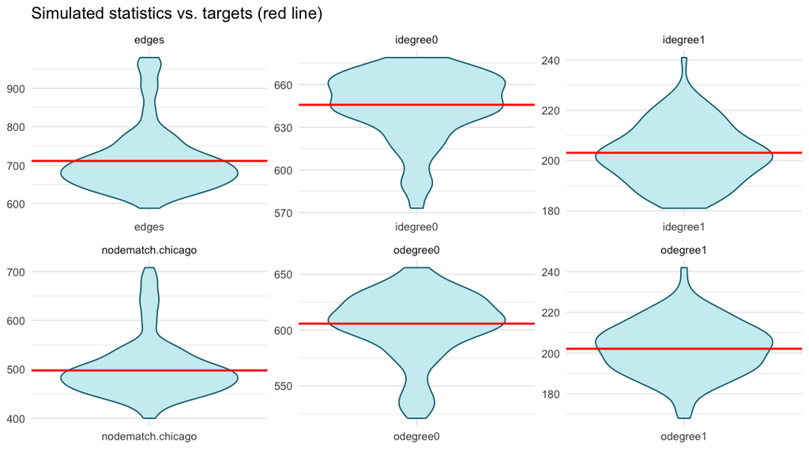

- Each violin: one statistic across 100 simulated networks. Red line: the **target**.

## Assessing Alignment between Simulated and Target Statistics

Repeat this process for each specified target statistic to:

- Identify whether any statistic’s target falls outside its simulated spread.
- If not — great, the model reproduces the targets within statistical variation.
- If a target is off, work through our discussed fixes, in rough order of effort:
  1. **Tune the controls / re-fit** (Modules 3–4) (cheapest, sometimes enough).
  2. **Reparameterize**: try a different specification.
  3. **Cross-check the data / targets** — most involved.
- In practice, for us, this process is often iterative.
- Sometimes the order of operations 1-3 can be different in terms of effort required.
- We stop when the target sits inside the simulated spread.

## The violin plot, conceptually

For **each statistic**:

- Show its distribution across the 100 simulated networks, and overlay the **target**.

```r
# per statistic: simulated values -> a violin; target -> a red line
ggplot(sim_long, aes(statistic, value)) +
  geom_violin() +
  geom_hline(aes(yintercept = target), color = "red")
```

- Violin spread = sampling variability; the red line = the specified target.

## Summarizing alignment numerically

For **each statistic**: compare the target to the simulated **mean** and a **simulation interval** (usually 95%).

```r
sim_mean <- colMeans(sim_stats)                          # per-statistic mean
sim_ci   <- apply(sim_stats, 2, quantile, c(.025, .975)) # 95% interval
```

- Target inside the interval → aligned on that statistic.

## Next Step: Crosswalk to the ABM

We have an ensemble of simulated networks that align with the targets.

We select one well-fitting simulation and export it.

```r
net_sim # selected network

attrs <- data.frame(id = network.vertex.names(net_sim),  # agents
                    sex = net_sim %v% "sex", young = net_sim %v% "young", ...)
el    <- as.edgelist(net_sim)                            # partnerships (from, to)

write.csv(attrs, "vertex_attributes.csv", row.names = FALSE)   # save agents
write.csv(el,    "edgelist.csv",          row.names = FALSE)   # save partnerships
```

We save **two** flat files:

```
vertex_attributes.csv                edgelist.csv
----                                   -----
id,sex,young,race.num,chicago,...    from,to
1,M,1,2,1,...                        12,847
2,F,0,1,0,...                        12,203
3,M,1,3,1,...                        305,41
...                                  ...
```

- The vertex set is fixed across the ensemble
- The ensemble of exported edgelists propagates **network variability** into the ABM.

## Next Step: Crosswalk to the ABM (cont’d)

A second option: reshape the **same** simulated network into networkx **node-link JSON**.

```r
# nodes carry attributes; edges are source -> target pairs
jsonlite::write_json(
  list(directed = TRUE, multigraph = FALSE,
       nodes = attrs,          # id, young, race_num, chicago, sex, lat, lon
       edges = edges),         # source, target
  "net_sim.json", auto_unbox = TRUE)
```

- Setting `directed = TRUE` preserves the syringe-sharing direction (from → to).
- This format is compatible with networkx, used by Repast4Py to ingest simulated networks.<sup>1</sup>
[^1]: Collier & Ozik (2022), Distributed Agent-Based Simulation with Repast4Py. *2022 Winter Simulation Conference (WSC)*, 192–206. doi:10.1109/WSC57314.2022.10015389

## Next Step: Canonical statnet method

- The `statnet` team also offers `EpiModel`, an end-to-end suite in R to streamline network modeling within ABMs.<sup>1</sup>
- Developed by Professors Samuel Jenness (Emory), Steven Goodreau (Washington), and Martina Morris (Washington).
- Wide userbase and community to co-evolve ABMs and network structure.
[^2]: Jenness, Goodreau & Morris (2018), *Journal of Statistical Software* 84(8), 1–47. doi:10.18637/jss.v084.i08

## Handoff to Module 6

Module 6: **spatial modeling** — geography as a first-class term.

- We used `nodematch("chicago")` as a stand-in
- Module 6 replaces it with a custom distance-based term.

## Funding acknowledgement

Research reported in this presentation was supported by the National Institute of Allergy and Infectious Diseases of the National Institutes of Health under award number R01AI158666. This project is financed 100% with federal funds: the FY2026 total for the prime award to Loyola University Chicago is $684,751, and Brown University’s subaward for the current budget period is $14,846. No portion is financed by non-governmental sources (0%, $0).

The content is solely the responsibility of the authors and does not necessarily represent the official views of the National Institutes of Health.

← All slides